# Instructions

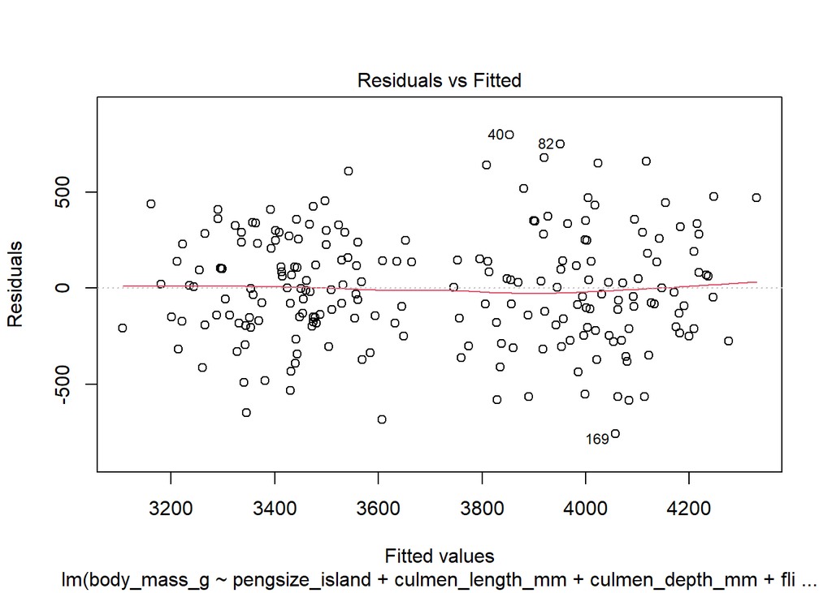

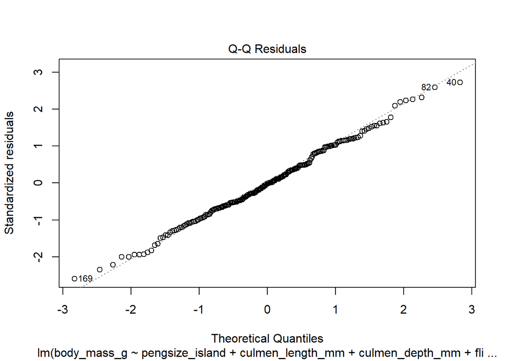

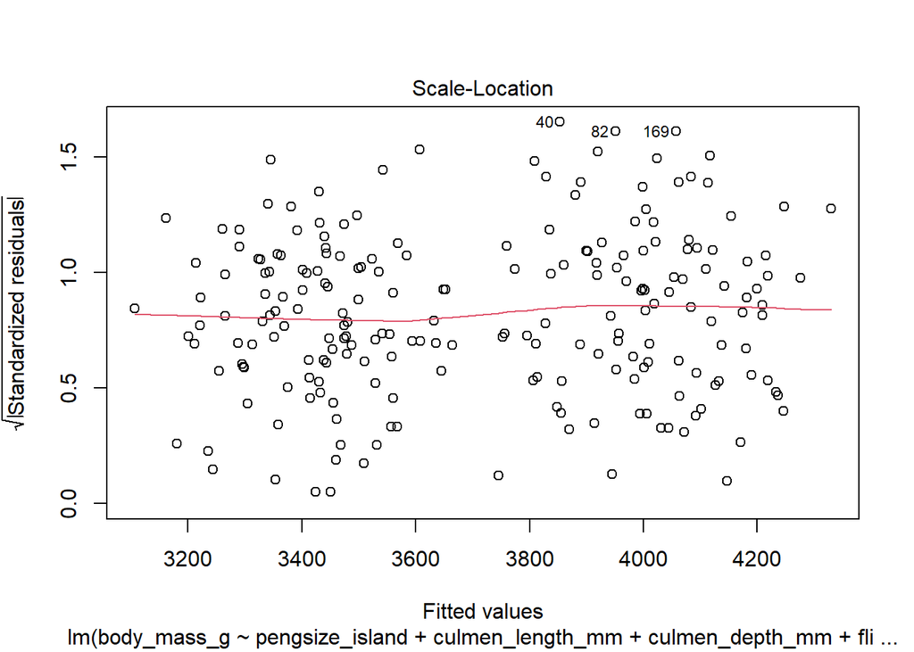

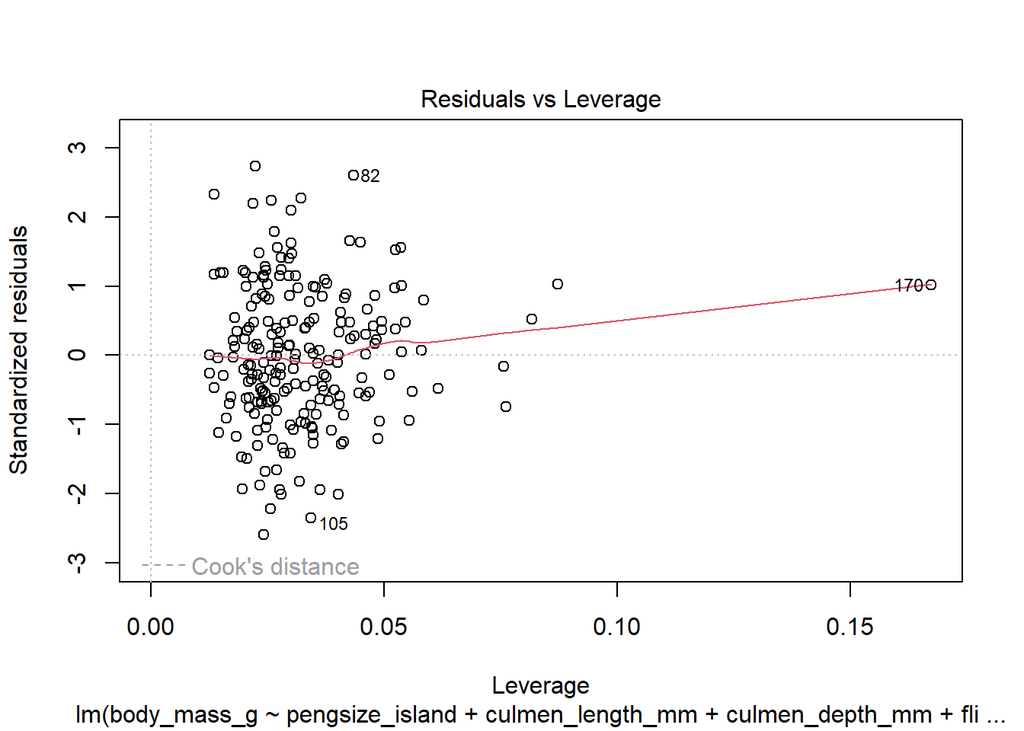

```r
plot(fullmodel)
```

##identifying the full model

```r
##first have to ensure that the sex, species, and island (all of which are categorical and/or binary) are in numerical value.
penguins_size$sex = as.factor(penguins_size$sex)
penguins_size$species = as.factor(penguins_size$species)
penguins_size$island = as.factor(penguins_size$island)

summary(penguins_size)
```

```
##       species          island    culmen_length_mm culmen_depth_mm
##  Adelie   :152   Biscoe   :168   Min.   :32.10    Min.   :13.10
##  Chinstrap: 68   Dream    :124   1st Qu.:39.23    1st Qu.:15.60
##  Gentoo   :124   Torgersen: 52   Median :44.45    Median :17.30
##                                  Mean   :43.92    Mean   :17.15
##                                  3rd Qu.:48.50    3rd Qu.:18.70
##                                  Max.   :59.60    Max.   :21.50
##                                  NA's   :2        NA's   :2
##  flipper_length_mm  body_mass_g       sex
##  Min.   :172.0     Min.   :2700   .     :  1
##  1st Qu.:190.0     1st Qu.:3550   FEMALE:165
##  Median :197.0     Median :4050   MALE  :168
##  Mean   :200.9     Mean   :4202   NA's  : 10
##  3rd Qu.:213.0     3rd Qu.:4750
##  Max.   :231.0     Max.   :6300
##  NA's   :2         NA's   :2
```

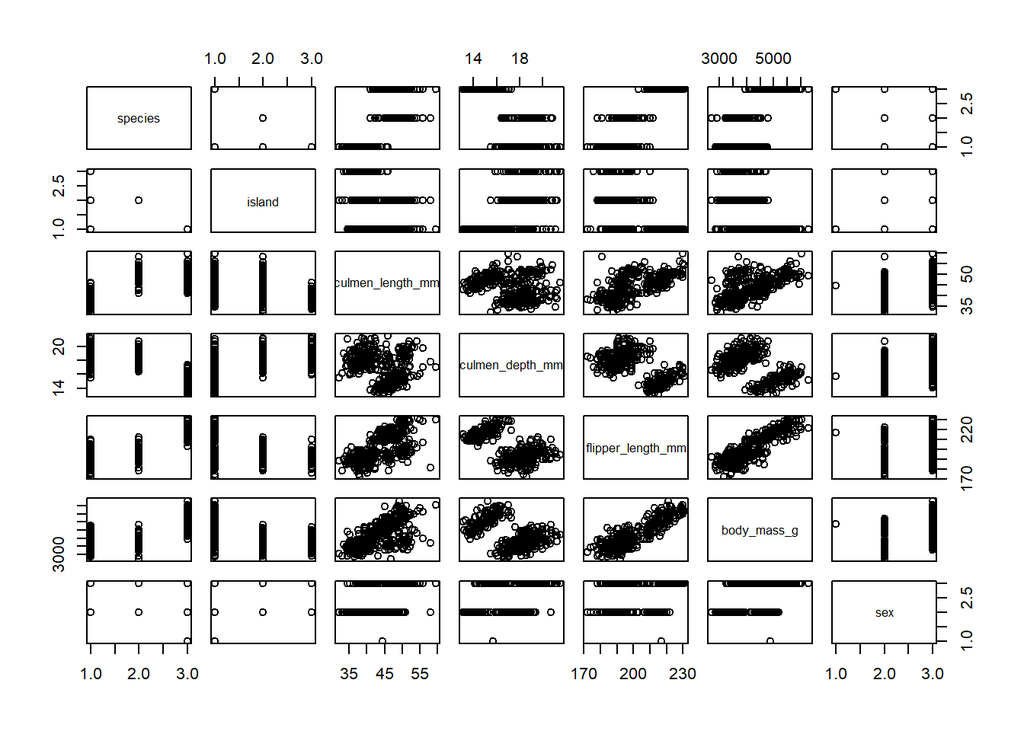

```r
plot(penguins_size)
```

```r
##identifying what categories (variables) have missing data that entered as NA. This allows us to start identifying areas that can be cleaned up prior to data analysis.
colSums(is.na(penguins_size))
```

```
##           species            island  culmen_length_mm   culmen_depth_mm
##                 0                 0                 2                 2
## flipper_length_mm       body_mass_g               sex
##                 2                 2                10
```

```r
##We then can run a na.omitter to be able to get rid of those data that are missing

clean_penguin_data = na.omit(penguins_size)
clean_penguin_data
```

[output not shown]

[output cut: 655 more lines]

#### Deliverables

GitHub Repository containing:

- All code (well-documented Rmd files)
- README.md with clear instructions on how to run your analysis
- Data folder (or instructions for accessing the data)
- Requirements.txt or environment.yml file

#### Final Report (PDF) containing:

- Introduction: dataset description and problem statement
- Methodology: techniques used and justification
- Results: findings from your analysis
- Discussion: interpretation of results and limitations
- Conclusion: summary and potential future work
- References: cite all sources used

## Evaluation Criteria

Your project will be evaluated based on:

- Correctness of statistical analysis and procedures
- Proper handling of regression assumptions
- Quality of variable selection and hypothesis testing
- Clarity of interpretation and insights
- Organization and documentation of code
- Professional presentation of findings

## Timeline and Submission

- Release Date: May 5th, 2025
- Due Date: Wednesday, May 14th, 2025 (11:59 PM EST)
- Submission: Email your GitHub repository link and PDF report to nbb45@cornell.edu with the subject line “Final Project - [Your Name]”

## Resources

- Course materials and lecture notes
- [Kaggle Datasets](https://www.kaggle.com/datasets)
- [GitHub tutorial](https://nayelbettache.github.io/documents/STSCI_6020/Github_tutorial.pdf) and [GitHub documentation](https://docs.github.com/en/repositories) for repository setup.

## Academic Integrity

This is an individual project. While you may discuss general concepts with classmates, all submitted work must be your own. Proper citation is required for any external resources used. Good luck with your project! This is an opportunity to demonstrate your skills and create a valuable addition to your professional portfolio.

References: Parul Pandey, https://www.kaggle.com/code/parulpandey/penguin-dataset-the-new-iris/notebook

Data from Kaggle originated from the following Reference: Gorman KB, Williams TD, Fraser WR (2014). Ecological sexual dimorphism and environmental variability within a community of Antarctic penguins (genus Pygoscelis). PLoS ONE 9(3):e90081. https://doi.org/10.1371/journal.pone.0090081

# Finished

You’re done, congratulations!